# Simple Data 1

4/21/2016

## Overview

This presentation discusses the contents of the `SimpleData1.R` example intended to introduce a basic pattern of programming: the three kinds of tasks.

- Input
- Analysis (a.k.a. Processing)
- Output

## Data Flow

[interactive chart not shown]

## Input

```r
dta <- read.csv( "../data/sampledta1/Test1.csv" )
```

- Input pulls data from outside of the program (e.g. hard disk or keyboard).
- CSV files are the easiest way to read data into R.

Potential hiccup: Windows conventionally uses `\` to separate directory and file names, but this is a special character in R literal strings. Either double them up when putting the string into R code (`"C:\\TEMP\\file.csv"`) or use the forward slash alternative (`"C:/TEMP/file.csv"`).

## Analysis

```r
dta.lm <- lm( Reading ~ Seconds, data = dta )
```

- `lm` is the “linear model” (regression) function. The `dta.lm` object holds the regression results.
- The first argument is a “formula” because of the `~` operator. The left side indicates what `y` is and the right side indicates that a coefficient is needed for `Seconds`. In the absence of a `-1` on the right side, an intercept will be computed.

## Analysis (cont’d.)

- A general feature of analysis functions is that they don’t interact with the world directly. Information goes in as parameters, and one “blob” of data is returned as a result.
- In fact, a good quality analysis function won’t have side effects. R makes it difficult (but not impossible) to change global variables from inside functions. Don’t try to circumvent this… write your functions to direct all output through the return value, like the `lm` function does.

## Text Output : Data Frame Summary

```r
summary( dta )
```

```
##     Seconds        Reading
##  Min.   :0.00   Min.   :2.200
##  1st Qu.:0.75   1st Qu.:2.425
##  Median :1.50   Median :2.550
##  Mean   :1.50   Mean   :2.575
##  3rd Qu.:2.25   3rd Qu.:2.700
##  Max.   :3.00   Max.   :3.000
```

Overview of the contents of a data frame.

- Note that output doesn’t always work with the output of the analysis step, though it is unusual to direct output to the same place it came from.
- In this case, the output is to the console, so the analyst can review it.

## Text Output : Linear Model

```r
dta.lm # minimal printout
```

```
##
## Call:
## lm(formula = Reading ~ Seconds, data = dta)
##
## Coefficients:
## (Intercept)      Seconds
##        2.32         0.17
```

Default console view of linear regression analysis result.

## Text Output : Linear Model Summary

```r
summary( dta.lm )
```

```
##
## Call:
## lm(formula = Reading ~ Seconds, data = dta)
##
## Residuals:
##     1     2     3     4
## -0.12  0.01  0.34 -0.23
##
## Coefficients:
##             Estimate Std. Error t value Pr(>|t|)
## (Intercept)   2.3200     0.2531   9.167   0.0117 *
## Seconds       0.1700     0.1353   1.257   0.3358
## ---
## Signif. codes:  0 '***' 0.001 '**' 0.01 '*' 0.05 '.' 0.1 ' ' 1
##
## Residual standard error: 0.3025 on 2 degrees of freedom
## Multiple R-squared:  0.4412, Adjusted R-squared:  0.1618
## F-statistic: 1.579 on 1 and 2 DF,  p-value: 0.3358
```

Counterintuitively, `summary` yields a more detailed printout than just printing the object does.

## Graphical Output

- There are three systems for generating graphs
  - Base graphics - like a paintbrush (doesn’t resize well)
  - Lattice graphics - generates `grid` objects that can be printed
  - Ggplot2 graphics - generates `grid` objects using different syntax

Make sure when you search for graphing functions that you don’t try to mix and match… use one system at a time.

## Base Graphics

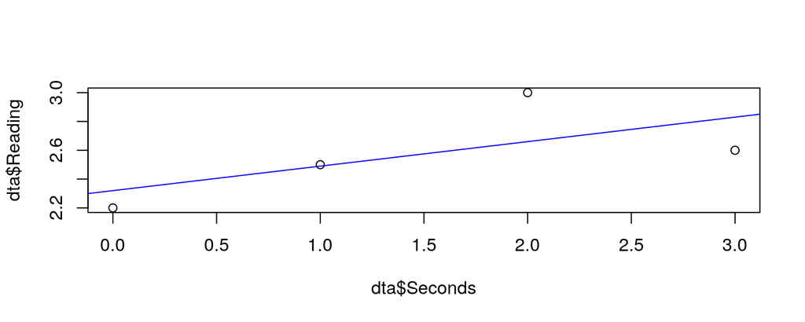

```r
# R base graphics... like "painting" on the screen
plot( dta$Seconds, dta$Reading )
abline( dta.lm, col = "blue" )
```

## Lattice graphics

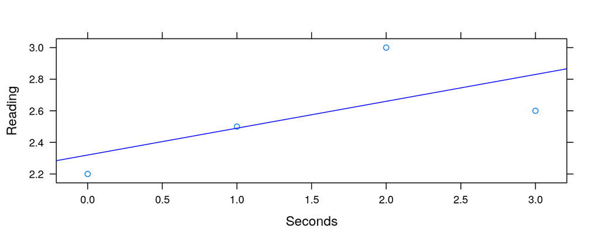

```r
library(lattice)
p <- xyplot( Reading ~ Seconds, dta
           , panel = function( x, y ) {
              panel.xyplot( x, y )
              panel.abline( dta.lm, col = "blue" ) } )
print( p )
```

## Ggplot2 Graphics

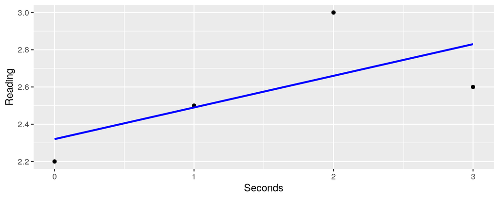

```r
library(ggplot2)
ggp <- ggplot( dta, aes( x=Seconds, y=Reading ) ) +
  geom_point() +
  geom_smooth( method="lm", se=FALSE, color = "blue" )
print( ggp )
```

## Ggplot2 Graphics Comments

```r
ggp <- # ggplot produces a "printable" object
  ggplot( dta  # default source for data to plot
        , aes( # define "aesthetic" map from data to display
               x = Seconds # horizontal position
             , y = Reading # vertical position
             )
        ) + # ggplot objects are "added" together
  geom_point() + # first layer plots data as points
  geom_smooth( # second layer uses data to generate a "smooth" curve
               method = "lm" # using linear regression
             , se = FALSE # don't display confidence band
             , color = "blue" # specify color of curve
             )
# object is not displayed until it is printed
# print( ggp ) # can be explicit, like this, or by interactive default
```

## notes

- These three groups of plotting functions can be used consecutively, but they don’t work together (you cannot paint an `abline` on a ggplot object).
- Make sure when you search for graphing functions that you don’t try to mix and match
- My examples will primarily use ggplot2 functions.